# Chocolate Bar Rating

## Table of Content:

- Introduce the dataset and scenario.
- Exploratory Data Analysis.
- External Data Set Analysis.
- Key investigations results from the data.

## Introduction

Chocolate is the most popular candy in the world. The world consumption is estimated to be at least 7.2 mill metric tons/year, so chocolate has a strong business market. However, not all chocolate bars are created equal.

This dataset contains expert ratings of over 1,700 individual chocolate bars, along with other information.

## Data Summary

This rating were compiled by Brady Belinsky, founding member of the Manhattan chocolate society

- Data collection duration 2006-2021
- From 580 company
- 67 different country

The dataset contains 2530 entry each one has 10 attribute list as following:

- Numeric: Ref, Review Year, Cocoa Percent, Rating.
- Character: Company Name, Company Location, Bean Origin, Bar Name, Ingredients, Characteristic

## Data Table

|  | company_location | country_of_bean_origin | cocoa_percent | rating |
| --- | --- | --- | --- | --- |
| 1 | U.S.A. | Tanzania | 76 | 3.25 |
| 2 | U.S.A. | Dominican Republic | 76 | 3.5 |
| 3 | U.S.A. | Madagascar | 76 | 3.75 |
| 4 | U.S.A. | Fiji | 68 | 3 |
| 5 | U.S.A. | Venezuela | 72 | 3 |
| 6 | U.S.A. | Uganda | 80 | 3.25 |
| 7 | U.S.A. | India | 68 | 3.5 |
| 8 | France | Bolivia | 70 | 3.5 |
| 9 | France | Peru | 63 | 3.75 |
| 10 | France | Panama | 70 | 2.75 |

[output cut: 2520 more lines]

## Flavors of Cacao Rating System

- 5= Elite (Transcending beyond the ordinary limits)
- 4= Premium (Superior flavor development, character and style)
- 3= Satisfactory(3.0) to praiseworthy(3.75) (well made with special qualities)
- 2= Disappointing (Passable but contains at least one significant flaw)
- 1= Unpleasant (mostly unpalatable)

## Data Quality

- Missing Data :87 missing value (all under ingredients)
- Inconsistency : some values inconsistent (combined country and bar names)
- Cocoa Percent is a character, not a numeric value, percent sign removed
- Check the names and remove the spaces and line breaks

## Questions Navigating Our Analysis

- What country/countries are manufacturing the highest-rating chocolate bars?
- What country/countries are growing the highest-rating beans?
- What is the trend between the rating and cocoa percentage?
- What ingredients are found most among the highest-rating chocolate bars?
- Does the time in which the review was made affect the rating?

## Rating Density Plot

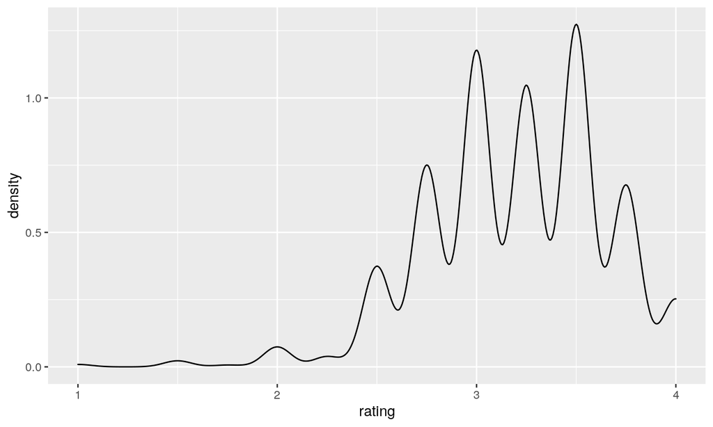

## Highest Rating Company Location

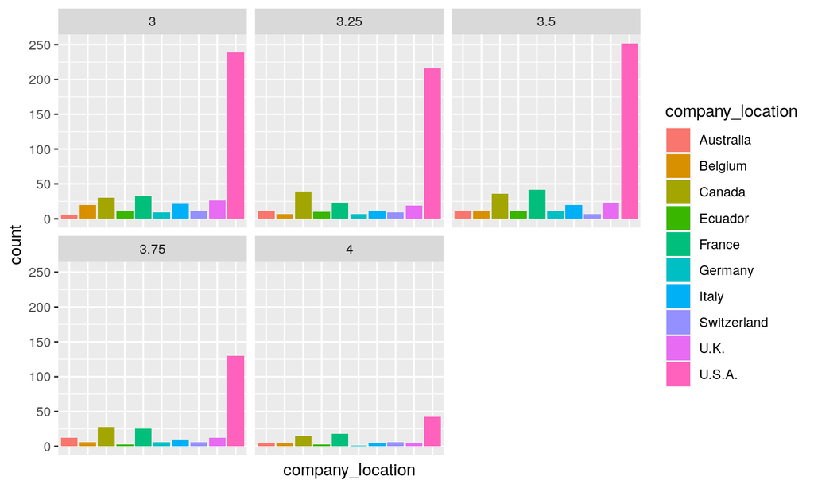

## Highest Rating Bean Origin Location

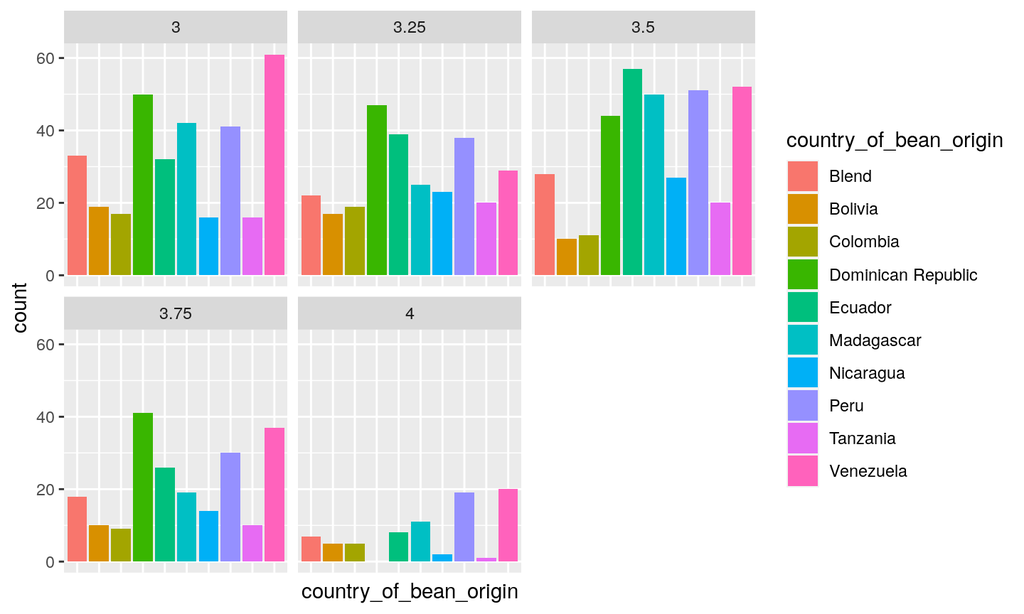

## Cocoa% Rating Densities

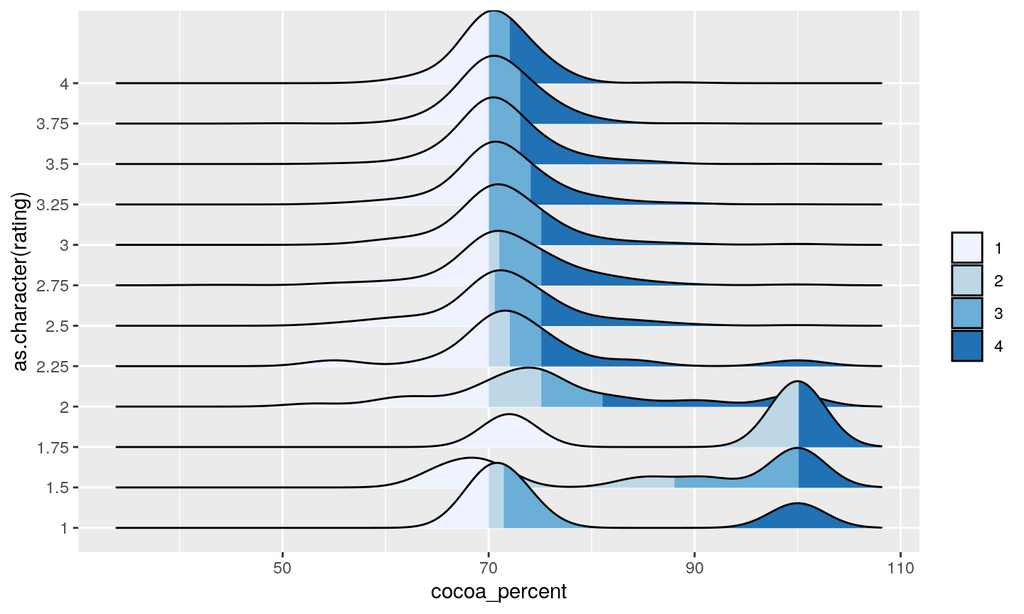

## Most Used Ingredients Rating

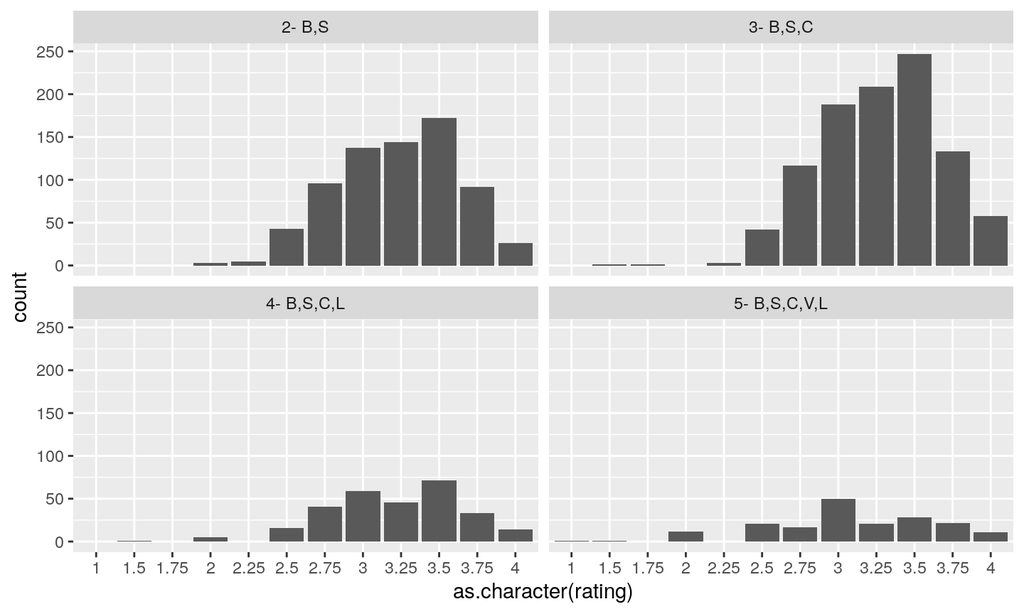

## Rating Density Based on Date

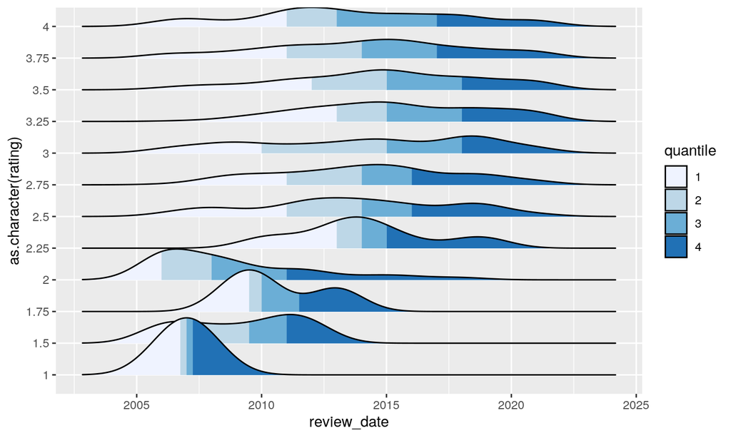

## External Data Set

Main goal: Investigate whether the high ranked candies contain chocolate or not.

The dataset contains 85 entries and 13 variables listed as follows:

- Logical: chocolate, fruity, caramel, peanutalmondy, nougat, crispedricewafer, hard, bar, pluribus
- Continuous: sugarpercent, pricepercent, winpercent
- Character: competitorname

## Table

|  | competitorname | winpercent | chocolate |
| --- | --- | --- | --- |
| 1 | ReeseÕs Peanut Butter cup | 84.18029 | 1 |
| 2 | ReeseÕs Miniatures | 81.866257 | 1 |
| 3 | Twix | 81.642914 | 1 |
| 4 | Kit Kat | 76.7686 | 1 |
| 5 | Snickers | 76.673782 | 1 |
| 6 | ReeseÕs pieces | 73.43499 | 1 |
| 7 | Milky Way | 73.099556 | 1 |
| 8 | ReeseÕs stuffed with pieces | 72.887901 | 1 |
| 9 | Peanut butter M&amp;MÕs | 71.46505 | 1 |
| 10 | Nestle Butterfinger | 70.735641 | 1 |

[output cut: 75 more lines]

## Take Aways

- Rating Density: Negative skew, median = 3.25.
- Highest Rating Company Location: USA for the win?
- Highest Rating Bean Origin Location: Venezuela and Peru lead the race with Dominican Republic slightly behind.
- Cocoa Percentage Density: Top rating bar have cocoa percent between 60 and 80.
- Most Used Ingredients Rating: Beans, sugar, and cocoa butter make up most bars.
- Rating Density Based on Date: Less/No low rating bars produced recently.